# Crime in Minneapolis

ETC5513 Group 6

30/05/2020

Analysis of Crime in Minneapolis:

- What types of crimes are most common?
- What crime is committed by each race? Are they proportionate?
- What are the most common force types?
- Which months of the year have the most criminal records?
- Which day of the week has the most crimes or forces used by police?
- Which area has the most crime?
- Is it the same police committing each crime?

```r
knitr::opts_chunk$set(echo = FALSE,
                      cache=TRUE,
                      messages=FALSE,
                      warning=FALSE)
```

## Introduction

George Floyd was arrested and killed by Derek Chauvin, a U.S. police officer, on the 25th of May in Minneapolis, BBC News (2020). Chauvin knelt on George Floyd’s neck for eight minutes and 46 seconds as Floyd gasped for air. His abominable death has sparked outrage on police brutality across America.

This paper hopes to explore and understand crime in Minneapolis. Specifically, the areas where crime is most common, the ethnicity of those committing the crime, and the force used by police.

Minneapolis has the highest violent crime rate in the US.

Research Questions (If anyone thinks of more, please add!!) - Where is crime most common in Minneapolis? Heat map - What is the ethnicity of those who are commmitting the crimes? Major crimes/minor crimes - Where is force used? Heat Map

```r
library(tidyverse)
library(rgdal)
library(lubridate)
library(ggrepel)
library(scales)
library(gridExtra)
library(kableExtra)
crime_incidents <- read_csv("data/Police_Incidents_Last_2Years.csv")
```

```r
glimpse(crime_incidents)
```

```
## Rows: 43,283
## Columns: 23
## $ X                 <dbl> -93.31351, -93.26257, -93.24225, -93.25755, -93.2...
## $ Y                 <dbl> 44.92445, 44.95822, 44.99974, 44.90617, 44.92061,...
## $ publicaddress     <chr> "0027XX 43RD ST W", "0024XX CHICAGO AVE", "0011XX...
## $ caseNumber        <chr> "MP201818191203", "MP2018184309", "MP2018184342",...
## $ precinct          <chr> "5", "3", "2", "3", "3", "5", "5", "1", "2", "1",...
## $ reportedDate      <chr> "2018/06/10 00:00:00+00", "2018/06/05 00:00:00+00...
## $ reportedTime      <dbl> 1237, 202, 330, 412, 952, 1112, 1257, 1344, 1447,...
## $ beginDate         <chr> "2018/06/10 00:00:00+00", "2018/06/05 00:00:00+00...
## $ reportedDateTime  <chr> "2018/06/10 17:37:00+00", "2018/06/05 07:02:00+00...
## $ beginTime         <dbl> 1237, 56, 151, 250, 0, 1112, 1215, 1215, 1324, 17...
## $ offense           <chr> "ARSON", "THEFT", "DASTR", "BURGD", "BURGD", "BUR...
## $ description       <chr> "ARSON", "OTHER THEFT", "DOMESTIC ASSAULT/STRANGU...
## $ UCRCode           <chr> "10", "07", "05", "06", "06", "06", "07", "07", "...
## $ enteredDate       <chr> "2018/06/11 00:00:00+00", "2018/06/05 00:00:00+00...
## $ centergbsid       <dbl> 12543, 18932, 15760, 14272, 12430, 21662, 21928, ...
## $ centerLong        <dbl> -93.31351, -93.26258, -93.24226, -93.25755, -93.2...
## $ centerLat         <dbl> 44.92445, 44.95822, 44.99975, 44.90617, 44.92061,...
## $ centerX           <dbl> -10387612, -10381942, -10379680, -10381383, -1038...
## $ centerY           <dbl> 5609635, 5614946, 5621481, 5606762, 5609032, 5609...
## $ neighborhood      <chr> "Linden Hills", "Midtown Phillips", "Northeast Pa...
## $ lastchanged       <chr> "2018/06/12 00:00:00+00", "2018/06/05 00:00:00+00...
## $ LastUpdateDateETL <chr> "2019/07/25 14:36:02+00", "2019/07/25 14:36:02+00...
## $ OBJECTID          <dbl> 1, 2, 3, 4, 5, 6, 7, 8, 9, 10, 11, 12, 13, 14, 15...
```

```r
shp <- rgdal::readOGR(dsn = file.path(paste(getwd(),"/data/Police_Incidents_Last_2Years-shp", sep=""), layer = "Police_Incidents_Last_2Years.shp") , stringsAsFactors = FALSE)
summary(shp@data)
```

```
##   publicaddr         caseNumber          precinct          reportedDa
##  Length:43283       Length:43283       Length:43283       Length:43283
##  Class :character   Class :character   Class :character   Class :character
##  Mode  :character   Mode  :character   Mode  :character   Mode  :character
##
##
##
##
##    reportedTi    beginDate          reported_1          beginTime
##  Min.   :   0   Length:43283       Length:43283       Min.   :   0
##  1st Qu.: 958   Class :character   Class :character   1st Qu.: 800
##  Median :1354   Mode  :character   Mode  :character   Median :1459
##  Mean   :1344                                         Mean   :1325
##  3rd Qu.:1820                                         3rd Qu.:1915
##  Max.   :2359                                         Max.   :2359
##
##    offense           descriptio          UCRCode           enteredDat
##  Length:43283       Length:43283       Length:43283       Length:43283
##  Class :character   Class :character   Class :character   Class :character
##  Mode  :character   Mode  :character   Mode  :character   Mode  :character
##
##
##
##
##    centergbsi      centerLong       centerLat        centerX
##  Min.   :    0   Min.   :-93.33   Min.   : 0.00   Min.   :-10389348
##  1st Qu.:14818   1st Qu.:-93.29   1st Qu.:44.95   1st Qu.:-10384804
##  Median :17255   Median :-93.27   Median :44.97   Median :-10382968
##  Mean   :17207   Mean   :-93.23   Mean   :44.95   Mean   :-10378492
##  3rd Qu.:19927   3rd Qu.:-93.25   3rd Qu.:44.99   3rd Qu.:-10380253
##  Max.   :26053   Max.   :  0.00   Max.   :45.05   Max.   :        0
##  NA's   :5423
##     centerY         neighborho         lastchange         LastUpdate
##  Min.   :      0   Length:43283       Length:43283       Length:43283
##  1st Qu.:5613395   Class :character   Class :character   Class :character
##  Median :5616316   Mode  :character   Mode  :character   Mode  :character
##  Mean   :5614271
##  3rd Qu.:5619473
##  Max.   :5629589
##
##     OBJECTID
##  Min.   :    1
##  1st Qu.:10822
##  Median :21642
##  Mean   :21642
##  3rd Qu.:32463
##  Max.   :43283
##
```

```r
police_use_of_force <- read_csv("data/Police_Use_of_Force.csv")
```

## Methodology

#### Analysing the crime which is most common

The crime incidence data was wrangled. This involved assigning each crime to its relevant offence type. The incidence of each offense was calculated, and plotted according to year.

#### Analysing the crime being committed by each race

#### Computing the most common force type

The police use of force data was wrangled, and a summary was generated to count the incidence of each offense according to race. The data was plotted.

#### Analysing the months of the year which have the most criminal records

#### Analysing the areas that have the most crime

#### Analysing whether Police are repeat offenders?

# Results

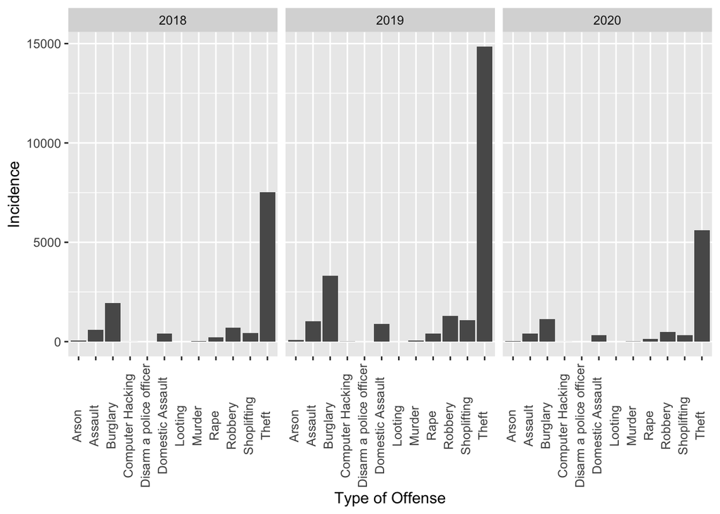

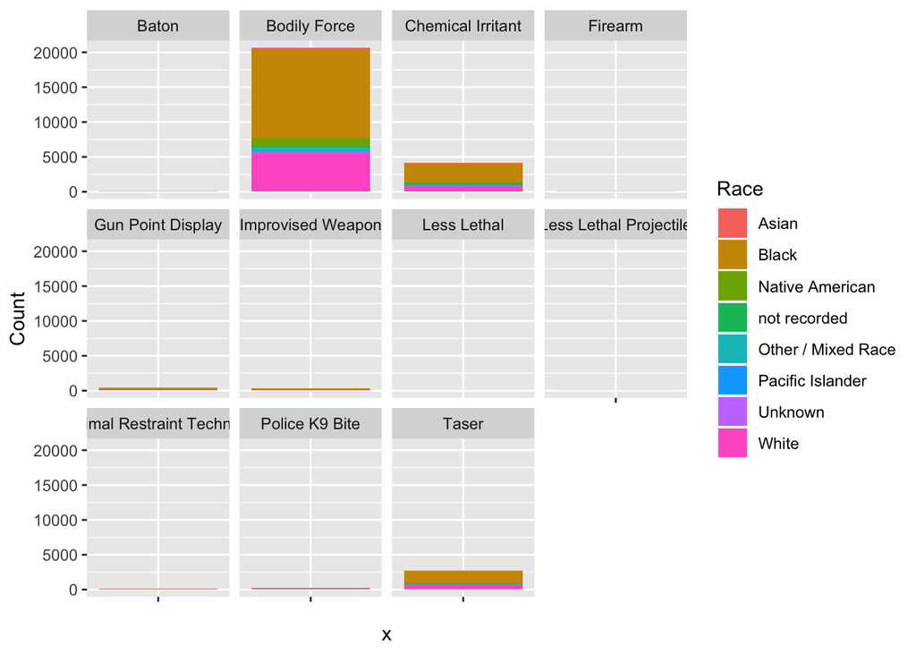

Therefore, assuming that crime being committed by African-Americans is similar in nature to the crime being committed by all other races, it is likely African-Americans are more likely to be subject of ruthless force use.

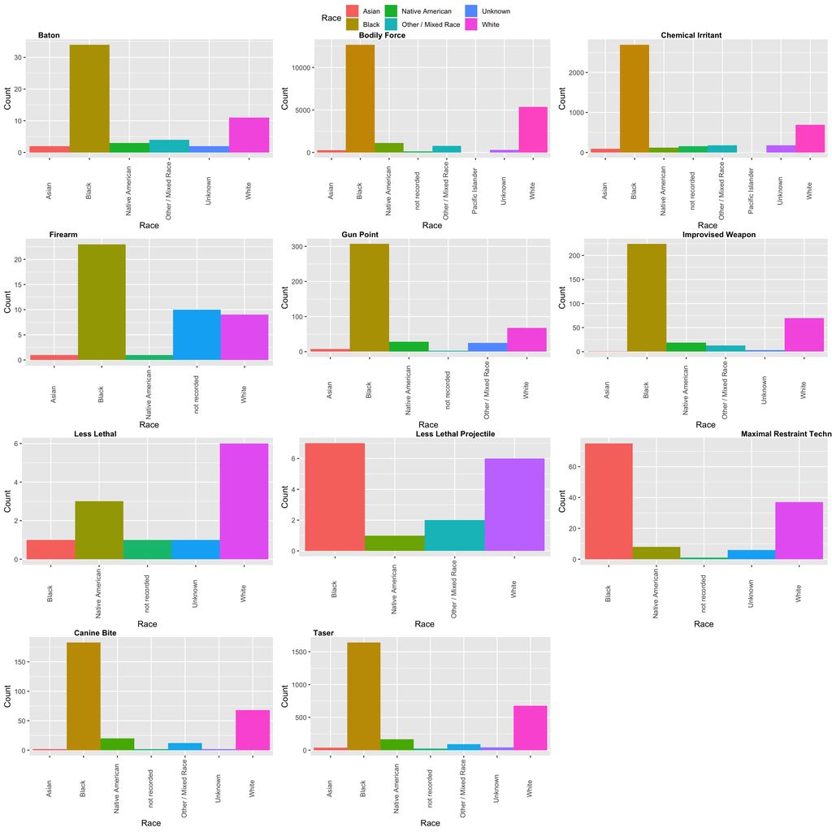

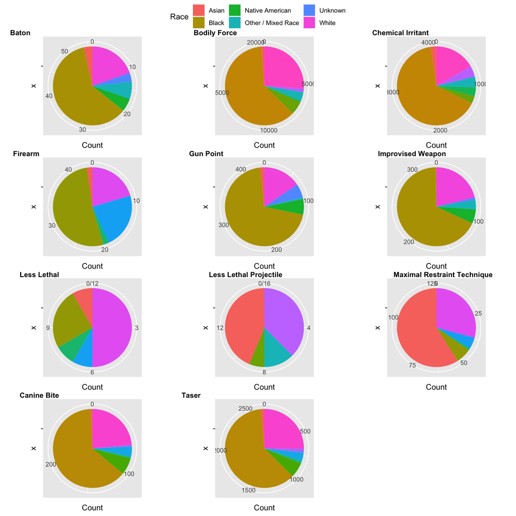